# Rock Hill Gymnastics

Author

Architech Sports and Physical Therapy

**Jump Performance**

**Eccentric Duration**

Eccentric duration measures how long an athlete takes from the start of their downward movement to when they start to rebound back upwards. Generally, a longer eccentric duration is associated with higher levels of fatigue or a lack of strength. However, it may be a result of jumping technique, as well.

**Countermovement Jump**

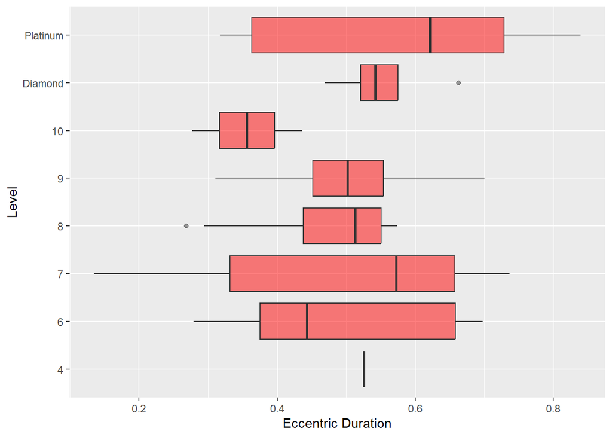

Raw Data

| Athlete | Level | Eccentric Duration (s) |
| --- | --- | --- |
| 10 | Addison Catledge | 0.277 |
| 10 | Kennedi Johnson | 0.436 |
| 4 | Taylor Orr | 0.526 |
| 6 | Andie Winker | 0.654 |
| 6 | Brigsley Alligood | 0.698 |
| 6 | Elana Del Toro | 0.443 |
| 6 | Harper Scorsone | 0.314 |
| 6 | Leah Williams | 0.662 |
| 6 | Madison Hood | 0.436 |
| 6 | Maeve Nemecek | 0.279 |
| 7 | Abigail Schaney | 0.192 |
| 7 | Ashlyn Blackmon | 0.678 |
| 7 | Caitlyn Orlando | 0.737 |
| 7 | Cameron Winker | 0.134 |
| 7 | Chamblee Cranford | 0.637 |
| 7 | Corrine Brantley | 0.525 |
| 7 | Gemma Hatton | 0.215 |
| 7 | Grace Fiske | 0.448 |
| 7 | Mckinley Hardee | 0.573 |
| 7 | Miller Young | 0.714 |
| 7 | Ryan Marsh | 0.584 |
| 8 | Arianna Ferguson | 0.294 |
| 8 | Gracelyn Elias | 0.486 |
| 8 | Hailey Finnerty | 0.526 |
| 8 | Hollie Pratt | 0.574 |
| 8 | Jenna Falkowitz | 0.268 |
| 8 | Kennedy Lewis | 0.543 |
| 8 | Meridith Allen | 0.500 |
| 8 | Scarlet Matthews | 0.572 |
| 9 | Alexzandria Albaugh | 0.700 |
| 9 | Ellison Ligon | 0.505 |
| 9 | Fallon Zimba | 0.499 |
| 9 | Paige Feemster | 0.310 |
| Diamond | Hailey Wilson | 0.538 |
| Diamond | Kayla Hardee | 0.469 |
| Diamond | Kerry McCrea | 0.546 |
| Diamond | Rachel Keevfauver | 0.663 |
| Platinum | Callie Helms | 0.627 |
| Platinum | Carleigh Flaherty | 0.575 |
| Platinum | Hannah Thomas | 0.350 |
| Platinum | Jessica Hofferbert | 0.836 |
| Platinum | Jordin Morstad | 0.615 |
| Platinum | Lydia Young | 0.328 |
| Platinum | Mabry Rice | 0.317 |
| Platinum | Madalyn Dutton | 0.368 |
| Platinum | Miranda Dutton | 0.693 |
| Platinum | Reagan Davis | 0.660 |
| Platinum | Sophie Bryant | 0.840 |
| Platinum | Sydney Stovesand | 0.840 |

**Single Jump**

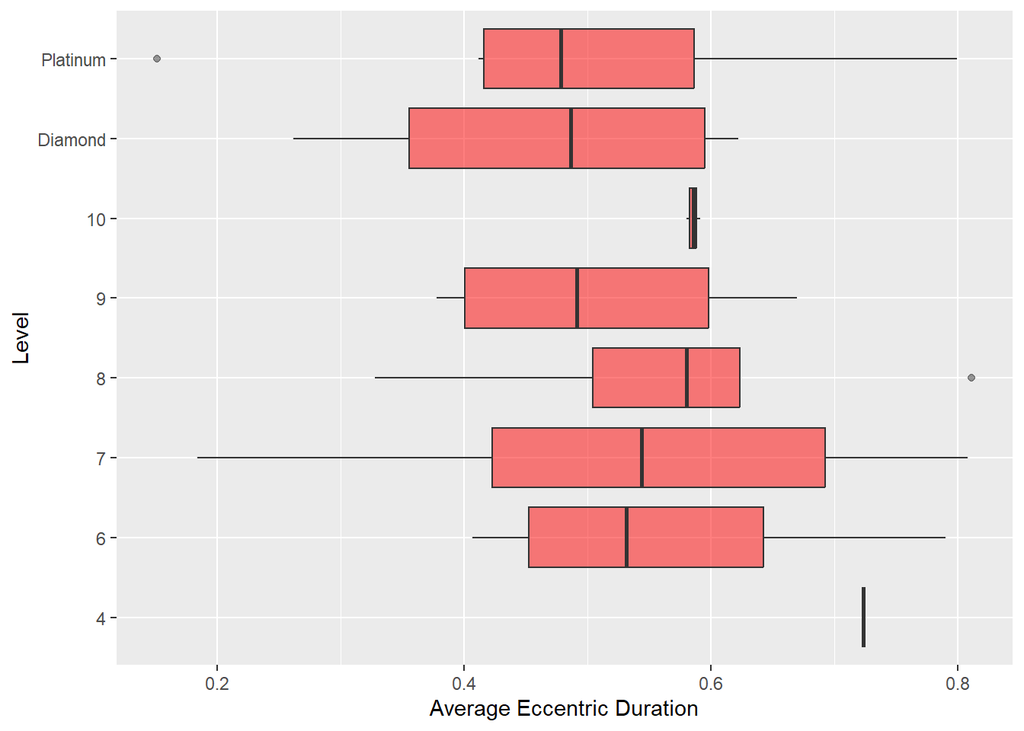

Raw Data

| Level | Athlete | Eccentric Duration - Left (s) | Eccentric Duration - Right (s) |
| --- | --- | --- | --- |
| 10 | Addison Catledge | 0.254 | 0.906 |
| 10 | Kennedi Johnson | 0.271 | 0.912 |
| 4 | Taylor Orr | 0.525 | 0.922 |
| 6 | Andie Winker | 0.532 | 0.356 |
| 6 | Brigsley Alligood | 0.602 | 0.979 |
| 6 | Elana Del Toro | 0.417 | 0.398 |
| 6 | Harper Scorsone | 0.260 | 0.661 |
| 6 | Leah Williams | 0.643 | 0.674 |
| 6 | Madison Hood | 0.834 | 0.418 |
| 6 | Maeve Nemecek | 0.606 | 0.457 |
| 7 | Abigail Schaney | 0.560 | 1.054 |
| 7 | Ashlyn Blackmon | 0.296 | 0.792 |
| 7 | Caitlyn Orlando | 0.529 | 0.799 |
| 7 | Cameron Winker | 0.337 | 0.032 |
| 7 | Chamblee Cranford | 0.817 | 0.541 |
| 7 | Corrine Brantley | 0.491 | 0.524 |
| 7 | Gemma Hatton | 0.697 | 0.717 |
| 7 | Grace Fiske | 0.519 | 0.527 |
| 7 | Mckinley Hardee | 0.746 | 0.869 |
| 7 | Miller Young | 0.384 | 0.295 |
| 7 | Ryan Marsh | 0.217 | 0.416 |
| 8 | Arianna Ferguson | 0.781 | 0.312 |
| 8 | Gracelyn Elias | 0.281 | 0.375 |
| 8 | Hailey Finnerty | 0.881 | 0.365 |
| 8 | Hollie Pratt | 0.633 | 0.596 |
| 8 | Jenna Falkowitz | 0.218 | 0.656 |
| 8 | Kennedy Lewis | 0.732 | 0.322 |
| 8 | Meridith Allen | 0.511 | 0.736 |
| 8 | Scarlet Matthews | 0.854 | 0.769 |
| 9 | Alexzandria Albaugh | 0.557 | 0.591 |
| 9 | Ellison Ligon | 0.161 | 0.595 |
| 9 | Fallon Zimba | 0.756 | 0.584 |
| 9 | Paige Feemster | 0.462 | 0.355 |
| Diamond | Hailey Wilson | 0.117 | 0.407 |
| Diamond | Kayla Hardee | 0.504 | 0.668 |
| Diamond | Kerry McCrea | 0.229 | 0.546 |
| Diamond | Rachel Keevfauver | 0.380 | 0.865 |
| Platinum | Callie Helms | 0.795 | 0.387 |
| Platinum | Carleigh Flaherty | 0.176 | 0.658 |
| Platinum | Hannah Thomas | 0.793 | 0.366 |
| Platinum | Jessica Hofferbert | 0.831 | 0.351 |
| Platinum | Jordin Morstad | 0.320 | 0.507 |
| Platinum | Lydia Young | 0.809 | 0.362 |
| Platinum | Mabry Rice | 0.529 | 0.436 |
| Platinum | Madalyn Dutton | 0.418 | 0.520 |
| Platinum | Miranda Dutton | 0.450 | 0.374 |
| Platinum | Reagan Davis | 1.177 | 0.422 |
| Platinum | Sophie Bryant | 0.489 | 0.459 |
| Platinum | Sydney Stovesand | 0.354 | -0.051 |

**Jump Height**

Jump height is calculated by the Impulse-Momentum method, which uses the force produced into the plate to determine how high an athlete jumps. This is more accurate than using flight time, which other methods tend to use.

**Countermovement Jump**

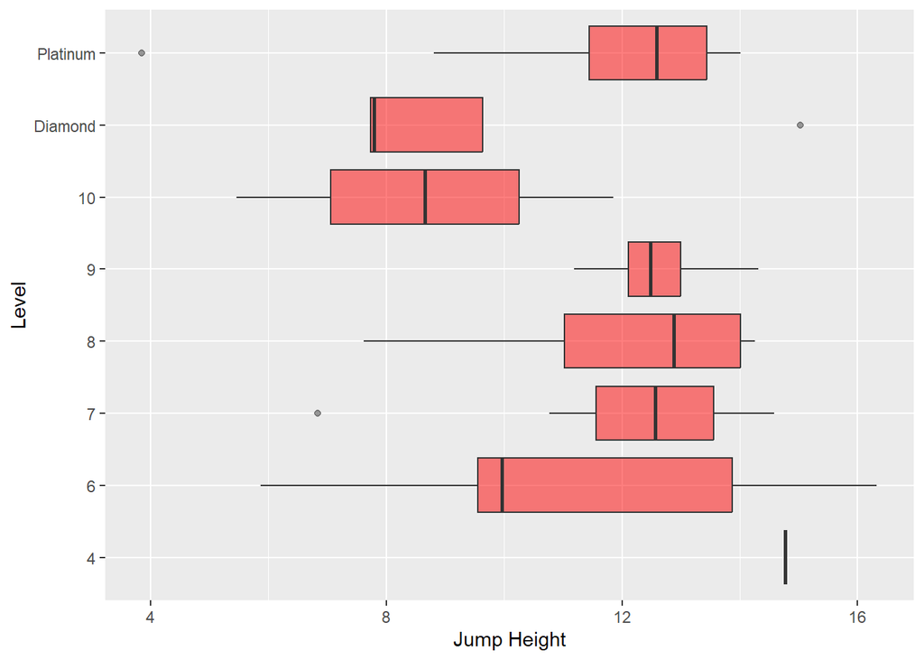

Raw Data

| Athlete | Level | Jump Height (in) |
| --- | --- | --- |
| 10 | Addison Catledge | 11.852 |
| 10 | Kennedi Johnson | 5.465 |
| 4 | Taylor Orr | 14.771 |
| 6 | Andie Winker | 9.534 |
| 6 | Brigsley Alligood | 9.583 |
| 6 | Elana Del Toro | 16.326 |
| 6 | Harper Scorsone | 12.773 |
| 6 | Leah Williams | 9.964 |
| 6 | Madison Hood | 14.979 |
| 6 | Maeve Nemecek | 5.865 |
| 7 | Abigail Schaney | 13.314 |
| 7 | Ashlyn Blackmon | 6.833 |
| 7 | Caitlyn Orlando | 13.295 |
| 7 | Cameron Winker | 11.760 |
| 7 | Chamblee Cranford | 12.569 |
| 7 | Corrine Brantley | 11.360 |
| 7 | Gemma Hatton | 10.769 |
| 7 | Grace Fiske | 13.973 |
| 7 | Mckinley Hardee | 11.853 |
| 7 | Miller Young | 13.798 |
| 7 | Ryan Marsh | 14.578 |
| 8 | Arianna Ferguson | 12.763 |
| 8 | Gracelyn Elias | 14.258 |
| 8 | Hailey Finnerty | 13.944 |
| 8 | Hollie Pratt | 14.232 |
| 8 | Jenna Falkowitz | 13.002 |
| 8 | Kennedy Lewis | 10.981 |
| 8 | Meridith Allen | 11.045 |
| 8 | Scarlet Matthews | 7.615 |
| 9 | Alexzandria Albaugh | 11.184 |
| 9 | Ellison Ligon | 12.551 |
| 9 | Fallon Zimba | 12.412 |
| 9 | Paige Feemster | 14.312 |
| Diamond | Hailey Wilson | 7.719 |
| Diamond | Kayla Hardee | 7.737 |
| Diamond | Kerry McCrea | 15.032 |
| Diamond | Rachel Keevfauver | 7.844 |
| Platinum | Callie Helms | 12.847 |
| Platinum | Carleigh Flaherty | 12.805 |
| Platinum | Hannah Thomas | 11.680 |
| Platinum | Jessica Hofferbert | 8.804 |
| Platinum | Jordin Morstad | 13.712 |
| Platinum | Lydia Young | 14.011 |
| Platinum | Mabry Rice | 13.838 |
| Platinum | Madalyn Dutton | 3.851 |
| Platinum | Miranda Dutton | 12.372 |
| Platinum | Reagan Davis | 11.297 |
| Platinum | Sophie Bryant | 11.490 |
| Platinum | Sydney Stovesand | 13.353 |

**Single Jump**

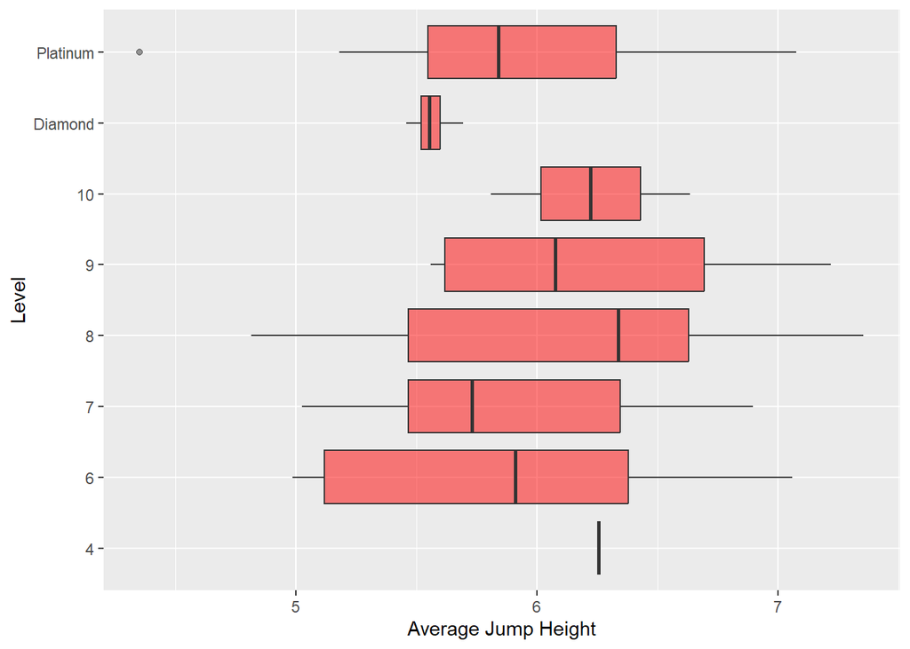

Raw Data

| Level | Athlete | Jump Height - Left (in) | Jump Height - Right (in) |
| --- | --- | --- | --- |
| 10 | Addison Catledge | 5.814 | 5.804 |
| 10 | Kennedi Johnson | 8.498 | 4.772 |
| 4 | Taylor Orr | 6.696 | 5.815 |
| 6 | Andie Winker | 6.666 | 5.153 |
| 6 | Brigsley Alligood | 4.598 | 5.502 |
| 6 | Elana Del Toro | 5.850 | 8.264 |
| 6 | Harper Scorsone | 6.315 | 6.854 |
| 6 | Leah Williams | 4.950 | 5.019 |
| 6 | Madison Hood | 4.831 | 5.537 |
| 6 | Maeve Nemecek | 7.204 | 5.142 |
| 7 | Abigail Schaney | 4.480 | 6.038 |
| 7 | Ashlyn Blackmon | 6.238 | 6.259 |
| 7 | Caitlyn Orlando | 5.499 | 5.644 |
| 7 | Cameron Winker | 6.651 | 7.140 |
| 7 | Chamblee Cranford | 6.138 | 5.322 |
| 7 | Corrine Brantley | 4.335 | 7.574 |
| 7 | Gemma Hatton | 5.909 | 4.139 |
| 7 | Grace Fiske | 6.428 | 4.911 |
| 7 | Mckinley Hardee | 5.708 | 7.326 |
| 7 | Miller Young | 4.811 | 5.903 |
| 7 | Ryan Marsh | 6.223 | 6.661 |
| 8 | Arianna Ferguson | 5.756 | 7.916 |
| 8 | Gracelyn Elias | 4.625 | 5.865 |
| 8 | Hailey Finnerty | 5.059 | 4.570 |
| 8 | Hollie Pratt | 4.506 | 6.575 |
| 8 | Jenna Falkowitz | 5.824 | 6.819 |
| 8 | Kennedy Lewis | 5.485 | 7.633 |
| 8 | Meridith Allen | 6.392 | 6.313 |
| 8 | Scarlet Matthews | 8.153 | 6.556 |
| 9 | Alexzandria Albaugh | 7.042 | 5.991 |
| 9 | Ellison Ligon | 5.148 | 5.967 |
| 9 | Fallon Zimba | 7.516 | 6.923 |
| 9 | Paige Feemster | 5.249 | 6.025 |
| Diamond | Hailey Wilson | 5.456 | 5.456 |
| Diamond | Kayla Hardee | 5.250 | 5.827 |
| Diamond | Kerry McCrea | 6.284 | 5.104 |
| Diamond | Rachel Keevfauver | 5.792 | 5.341 |
| Platinum | Callie Helms | 5.995 | 5.719 |
| Platinum | Carleigh Flaherty | 5.836 | 7.026 |
| Platinum | Hannah Thomas | 6.896 | 4.433 |
| Platinum | Jessica Hofferbert | 5.770 | 6.864 |
| Platinum | Jordin Morstad | 6.281 | 5.265 |
| Platinum | Lydia Young | 4.647 | 5.711 |
| Platinum | Mabry Rice | 5.967 | 5.678 |
| Platinum | Madalyn Dutton | 7.125 | 7.028 |
| Platinum | Miranda Dutton | 5.451 | 6.296 |
| Platinum | Reagan Davis | 5.392 | 5.004 |
| Platinum | Sophie Bryant | 5.720 | 7.013 |
| Platinum | Sydney Stovesand | 3.563 | 5.139 |

**Reactive Strength Index**

The Reactive Strength Index - Modified (mRSI) is a measure of how “springy” an athlete is. Calculated by dividing the jump height by the total contraction time, the mRSI looks at how quickly an athlete is able to bounce off the floor during a jump. Additionally, it helps track fatigue, as an athlete may be able to jump the same height on two different occasions, but if one jump took longer on the ground, the mRSI would reflect this.

**Countermovement Jump**

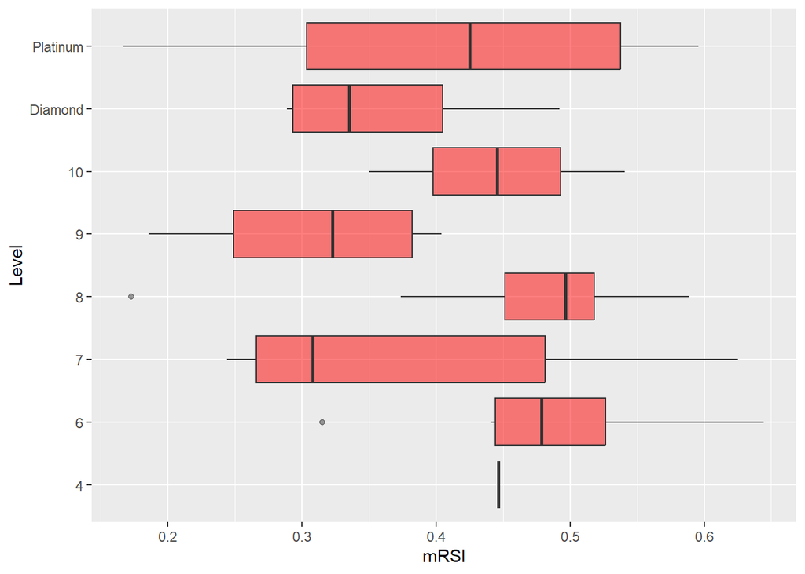

Raw Data

| Athlete | Level | Reactive Strength Index - Mod. |
| --- | --- | --- |
| 10 | Addison Catledge | 0.350 |
| 10 | Kennedi Johnson | 0.541 |
| 4 | Taylor Orr | 0.446 |
| 6 | Andie Winker | 0.315 |
| 6 | Brigsley Alligood | 0.520 |
| 6 | Elana Del Toro | 0.645 |
| 6 | Harper Scorsone | 0.441 |
| 6 | Leah Williams | 0.479 |
| 6 | Madison Hood | 0.448 |
| 6 | Maeve Nemecek | 0.533 |
| 7 | Abigail Schaney | 0.250 |
| 7 | Ashlyn Blackmon | 0.264 |
| 7 | Caitlyn Orlando | 0.293 |
| 7 | Cameron Winker | 0.308 |
| 7 | Chamblee Cranford | 0.625 |
| 7 | Corrine Brantley | 0.519 |
| 7 | Gemma Hatton | 0.515 |
| 7 | Grace Fiske | 0.268 |
| 7 | Mckinley Hardee | 0.399 |
| 7 | Miller Young | 0.448 |
| 7 | Ryan Marsh | 0.244 |
| 8 | Arianna Ferguson | 0.589 |
| 8 | Gracelyn Elias | 0.509 |
| 8 | Hailey Finnerty | 0.488 |
| 8 | Hollie Pratt | 0.477 |
| 8 | Jenna Falkowitz | 0.505 |
| 8 | Kennedy Lewis | 0.374 |
| 8 | Meridith Allen | 0.546 |
| 8 | Scarlet Matthews | 0.173 |
| 9 | Alexzandria Albaugh | 0.404 |
| 9 | Ellison Ligon | 0.270 |
| 9 | Fallon Zimba | 0.186 |
| 9 | Paige Feemster | 0.375 |
| Diamond | Hailey Wilson | 0.294 |
| Diamond | Kayla Hardee | 0.376 |
| Diamond | Kerry McCrea | 0.289 |
| Diamond | Rachel Keevfauver | 0.492 |
| Platinum | Callie Helms | 0.530 |
| Platinum | Carleigh Flaherty | 0.503 |
| Platinum | Hannah Thomas | 0.167 |
| Platinum | Jessica Hofferbert | 0.346 |
| Platinum | Jordin Morstad | 0.332 |
| Platinum | Lydia Young | 0.218 |
| Platinum | Mabry Rice | 0.560 |
| Platinum | Madalyn Dutton | 0.345 |
| Platinum | Miranda Dutton | 0.509 |
| Platinum | Reagan Davis | 0.588 |
| Platinum | Sophie Bryant | 0.185 |
| Platinum | Sydney Stovesand | 0.596 |

**Single Jump**

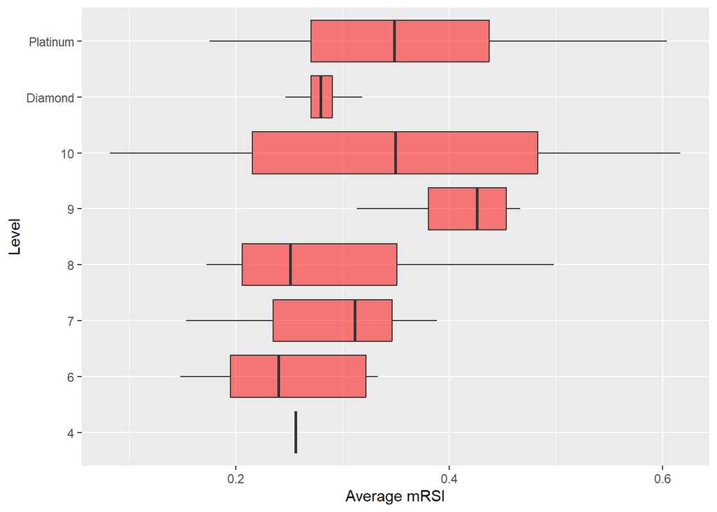

Raw Data

| Level | Athlete | mRSI |
| --- | --- | --- |
| 10 | Addison Catledge | 0.617 |
| 10 | Kennedi Johnson | 0.082 |
| 4 | Taylor Orr | 0.256 |
| 6 | Andie Winker | 0.190 |
| 6 | Brigsley Alligood | 0.333 |
| 6 | Elana Del Toro | 0.200 |
| 6 | Harper Scorsone | 0.148 |
| 6 | Leah Williams | 0.240 |
| 6 | Madison Hood | 0.315 |
| 6 | Maeve Nemecek | 0.328 |
| 7 | Abigail Schaney | 0.276 |
| 7 | Ashlyn Blackmon | 0.349 |
| 7 | Caitlyn Orlando | 0.379 |
| 7 | Cameron Winker | 0.343 |
| 7 | Chamblee Cranford | 0.153 |
| 7 | Corrine Brantley | 0.225 |
| 7 | Gemma Hatton | 0.388 |
| 7 | Grace Fiske | 0.341 |
| 7 | Mckinley Hardee | 0.245 |
| 7 | Miller Young | 0.312 |
| 7 | Ryan Marsh | 0.209 |
| 8 | Arianna Ferguson | 0.173 |
| 8 | Gracelyn Elias | 0.406 |
| 8 | Hailey Finnerty | 0.196 |
| 8 | Hollie Pratt | 0.238 |
| 8 | Jenna Falkowitz | 0.498 |
| 8 | Kennedy Lewis | 0.264 |
| 8 | Meridith Allen | 0.333 |
| 8 | Scarlet Matthews | 0.209 |
| 9 | Alexzandria Albaugh | 0.467 |
| 9 | Ellison Ligon | 0.403 |
| 9 | Fallon Zimba | 0.449 |
| 9 | Paige Feemster | 0.313 |
| Diamond | Hailey Wilson | 0.318 |
| Diamond | Kayla Hardee | 0.247 |
| Diamond | Kerry McCrea | 0.278 |
| Diamond | Rachel Keevfauver | 0.281 |
| Platinum | Callie Helms | 0.358 |
| Platinum | Carleigh Flaherty | 0.175 |
| Platinum | Hannah Thomas | 0.338 |
| Platinum | Jessica Hofferbert | 0.512 |
| Platinum | Jordin Morstad | 0.433 |
| Platinum | Lydia Young | 0.284 |
| Platinum | Mabry Rice | 0.412 |
| Platinum | Madalyn Dutton | 0.230 |
| Platinum | Miranda Dutton | 0.212 |
| Platinum | Reagan Davis | 0.318 |
| Platinum | Sophie Bryant | 0.604 |
| Platinum | Sydney Stovesand | 0.451 |

**Asymmetry**

**Eccentric**

Eccentric asymmetry measures the percent difference in left versus right during the lowering, eccentric portion at the start of the jump. This metric shows us how the athlete is loading each side differently while preparing to takeoff. Below, negative values are a left-bias, while positive values are right-biased.

**Countermovement Jump**

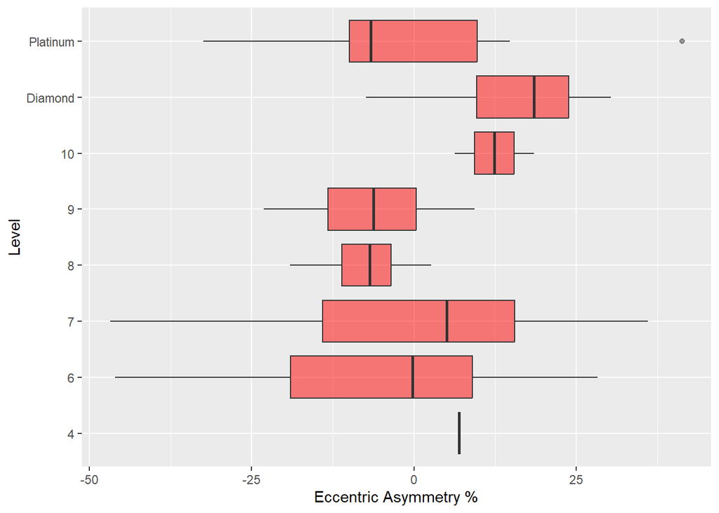

Raw Data

| Athlete | Level | Asymmetry |  |
| --- | --- | --- | --- |
| 10 | Addison Catledge | 6.304 |  |
| 10 | Kennedi Johnson | 18.470 |  |
| 4 | Taylor Orr | 6.937 |  |
| 6 | Andie Winker | -8.956 |  |
| 6 | Brigsley Alligood | -29.139 |  |
| 6 | Elana Del Toro | 28.261 |  |
| 6 | Harper Scorsone | -46.040 |  |
| 6 | Leah Williams | 8.781 |  |
| 6 | Madison Hood | -0.205 |  |
| 6 | Maeve Nemecek | 9.190 |  |
| 7 | Abigail Schaney | 36.044 |  |
| 7 | Ashlyn Blackmon | 16.541 |  |
| 7 | Caitlyn Orlando | 14.546 |  |
| 7 | Cameron Winker | -16.705 |  |
| 7 | Chamblee Cranford | 27.431 |  |
| 7 | Corrine Brantley | 5.057 |  |
| 7 | Gemma Hatton | -18.810 |  |
| 7 | Grace Fiske | 2.865 |  |
| 7 | Mckinley Hardee | -46.788 |  |
| 7 | Miller Young | 13.971 |  |
| 7 | Ryan Marsh | -11.369 |  |
| 8 | Arianna Ferguson | 2.686 |  |
| 8 | Gracelyn Elias | -8.560 |  |
| 8 | Hailey Finnerty | -19.115 |  |
| 8 | Hollie Pratt | -5.025 |  |
| 8 | Jenna Falkowitz | -9.607 |  |
| 8 | Kennedy Lewis | -15.612 |  |
| 8 | Meridith Allen | -4.672 |  |
| 8 | Scarlet Matthews | -0.130 |  |
| 9 | Alexzandria Albaugh | -2.627 |  |
| 9 | Ellison Ligon | -9.944 |  |
| 9 | Fallon Zimba | 9.307 |  |
| 9 | Paige Feemster | -23.150 |  |
| Diamond | Hailey Wilson | 30.375 |  |
| Diamond | Kayla Hardee | 15.382 |  |
| Diamond | Kerry McCrea | -7.389 |  |
| Diamond | Rachel Keevfauver | 21.630 |  |
| Platinum | Callie Helms | -7.045 |  |
| Platinum | Carleigh Flaherty | -32.425 |  |
| Platinum | Hannah Thomas | 41.339 |  |
| Platinum | Jessica Hofferbert | -8.255 |  |
| Platinum | Jordin Morstad | -14.869 |  |
| Platinum | Lydia Young | 12.578 |  |
| Platinum | Mabry Rice | -6.213 |  |
| Platinum | Madalyn Dutton | 14.743 |  |
| Platinum | Miranda Dutton | -8.918 |  |
| Platinum | Reagan Davis | -12.991 |  |
| Platinum | Sophie Bryant | 8.813 |  |
| Platinum | Sydney Stovesand | 1.444 |  |

**Single Jump**

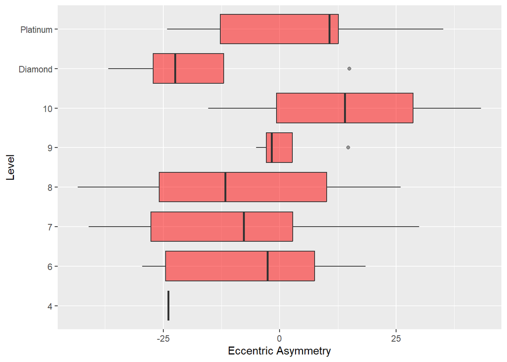

Raw Data

| Level | Athlete | Asymmetry |  |
| --- | --- | --- | --- |
| 10 | Addison Catledge | 43.250 |  |
| 10 | Kennedi Johnson | -15.319 |  |
| 4 | Taylor Orr | -23.890 |  |
| 6 | Andie Winker | -2.649 |  |
| 6 | Brigsley Alligood | -29.538 |  |
| 6 | Elana Del Toro | 18.438 |  |
| 6 | Harper Scorsone | 13.873 |  |
| 6 | Leah Williams | 1.168 |  |
| 6 | Madison Hood | -24.036 |  |
| 6 | Maeve Nemecek | -24.920 |  |
| 7 | Abigail Schaney | -20.362 |  |
| 7 | Ashlyn Blackmon | -7.700 |  |
| 7 | Caitlyn Orlando | -1.618 |  |
| 7 | Cameron Winker | -1.744 |  |
| 7 | Chamblee Cranford | -26.575 |  |
| 7 | Corrine Brantley | 7.193 |  |
| 7 | Gemma Hatton | -41.010 |  |
| 7 | Grace Fiske | 29.905 |  |
| 7 | Mckinley Hardee | 21.903 |  |
| 7 | Miller Young | -28.712 |  |
| 7 | Ryan Marsh | -31.015 |  |
| 8 | Arianna Ferguson | -25.773 |  |
| 8 | Gracelyn Elias | -26.150 |  |
| 8 | Hailey Finnerty | 25.949 |  |
| 8 | Hollie Pratt | -43.344 |  |
| 8 | Jenna Falkowitz | 11.865 |  |
| 8 | Kennedy Lewis | 9.494 |  |
| 8 | Meridith Allen | -15.965 |  |
| 8 | Scarlet Matthews | -7.462 |  |
| 9 | Alexzandria Albaugh | -2.092 |  |
| 9 | Ellison Ligon | -5.022 |  |
| 9 | Fallon Zimba | 14.678 |  |
| 9 | Paige Feemster | -1.296 |  |
| Diamond | Hailey Wilson | -21.048 |  |
| Diamond | Kayla Hardee | -36.802 |  |
| Diamond | Kerry McCrea | 14.951 |  |
| Diamond | Rachel Keevfauver | -23.896 |  |
| Platinum | Callie Helms | 10.290 |  |
| Platinum | Carleigh Flaherty | 11.036 |  |
| Platinum | Hannah Thomas | 28.882 |  |
| Platinum | Jessica Hofferbert | 10.448 |  |
| Platinum | Jordin Morstad | -17.798 |  |
| Platinum | Lydia Young | 10.813 |  |
| Platinum | Mabry Rice | 10.824 |  |
| Platinum | Madalyn Dutton | 17.282 |  |
| Platinum | Miranda Dutton | -20.366 |  |
| Platinum | Reagan Davis | -11.003 |  |
| Platinum | Sophie Bryant | -24.146 |  |
| Platinum | Sydney Stovesand | 35.120 |  |

**Concentric**

Concentric asymmetry looks at how balanced an athlete is during the rising portion of the jump. This tells us whether they are relying more on one side more than the other during the jump.

**Countermovement Jump**

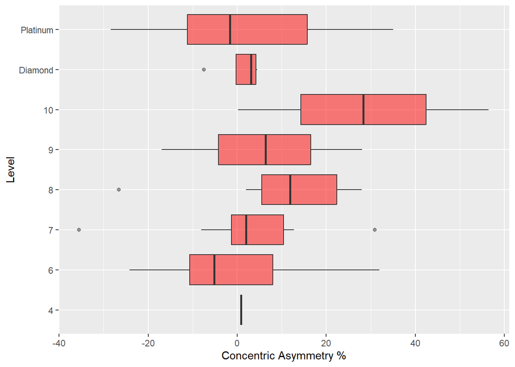

Raw Data

| Athlete | Level | Asymmetry |  |
| --- | --- | --- | --- |
| 10 | Addison Catledge | 0.173 |  |
| 10 | Kennedi Johnson | 56.481 |  |
| 4 | Taylor Orr | 0.836 |  |
| 6 | Andie Winker | 1.674 |  |
| 6 | Brigsley Alligood | 31.935 |  |
| 6 | Elana Del Toro | 14.332 |  |
| 6 | Harper Scorsone | -24.162 |  |
| 6 | Leah Williams | -5.475 |  |
| 6 | Madison Hood | -15.841 |  |
| 6 | Maeve Nemecek | -5.201 |  |
| 7 | Abigail Schaney | -1.423 |  |
| 7 | Ashlyn Blackmon | 12.770 |  |
| 7 | Caitlyn Orlando | 11.339 |  |
| 7 | Cameron Winker | -35.545 |  |
| 7 | Chamblee Cranford | 9.397 |  |
| 7 | Corrine Brantley | -0.432 |  |
| 7 | Gemma Hatton | -8.093 |  |
| 7 | Grace Fiske | 1.957 |  |
| 7 | Mckinley Hardee | -1.090 |  |
| 7 | Miller Young | 5.890 |  |
| 7 | Ryan Marsh | 30.918 |  |
| 8 | Arianna Ferguson | 27.992 |  |
| 8 | Gracelyn Elias | 7.582 |  |
| 8 | Hailey Finnerty | 6.705 |  |
| 8 | Hollie Pratt | 16.170 |  |
| 8 | Jenna Falkowitz | 25.240 |  |
| 8 | Kennedy Lewis | -26.608 |  |
| 8 | Meridith Allen | 1.947 |  |
| 8 | Scarlet Matthews | 21.404 |  |
| 9 | Alexzandria Albaugh | 28.029 |  |
| 9 | Ellison Ligon | 0.045 |  |
| 9 | Fallon Zimba | 12.648 |  |
| 9 | Paige Feemster | -16.976 |  |
| Diamond | Hailey Wilson | 2.115 |  |
| Diamond | Kayla Hardee | 4.484 |  |
| Diamond | Kerry McCrea | 4.108 |  |
| Diamond | Rachel Keevfauver | -7.491 |  |
| Platinum | Callie Helms | -28.430 |  |
| Platinum | Carleigh Flaherty | 19.540 |  |
| Platinum | Hannah Thomas | -11.683 |  |
| Platinum | Jessica Hofferbert | -11.055 |  |
| Platinum | Jordin Morstad | 34.986 |  |
| Platinum | Lydia Young | -23.342 |  |
| Platinum | Mabry Rice | -2.341 |  |
| Platinum | Madalyn Dutton | -0.901 |  |
| Platinum | Miranda Dutton | 15.560 |  |
| Platinum | Reagan Davis | 16.382 |  |
| Platinum | Sophie Bryant | 13.522 |  |
| Platinum | Sydney Stovesand | -2.780 |  |

**Single Jump**

[figure not shown]

Raw Data

| Level | Athlete | Asymmetry |  |
| --- | --- | --- | --- |
| 10 | Addison Catledge | 2.999 |  |
| 10 | Kennedi Johnson | 21.592 |  |
| 4 | Taylor Orr | -8.743 |  |
| 6 | Andie Winker | -22.357 |  |
| 6 | Brigsley Alligood | 14.164 |  |
| 6 | Elana Del Toro | -29.561 |  |
| 6 | Harper Scorsone | 10.806 |  |
| 6 | Leah Williams | -3.542 |  |
| 6 | Madison Hood | -18.831 |  |
| 6 | Maeve Nemecek | 3.778 |  |
| 7 | Abigail Schaney | 5.406 |  |
| 7 | Ashlyn Blackmon | -0.317 |  |
| 7 | Caitlyn Orlando | 14.858 |  |
| 7 | Cameron Winker | 22.795 |  |
| 7 | Chamblee Cranford | -49.437 |  |
| 7 | Corrine Brantley | -8.343 |  |
| 7 | Gemma Hatton | -35.029 |  |
| 7 | Grace Fiske | 37.587 |  |
| 7 | Mckinley Hardee | 0.706 |  |
| 7 | Miller Young | -12.311 |  |
| 7 | Ryan Marsh | -2.232 |  |
| 8 | Arianna Ferguson | 16.530 |  |
| 8 | Gracelyn Elias | -20.873 |  |
| 8 | Hailey Finnerty | 2.622 |  |
| 8 | Hollie Pratt | 34.370 |  |
| 8 | Jenna Falkowitz | 15.027 |  |
| 8 | Kennedy Lewis | 1.984 |  |
| 8 | Meridith Allen | 22.598 |  |
| 8 | Scarlet Matthews | -2.178 |  |
| 9 | Alexzandria Albaugh | 4.532 |  |
| 9 | Ellison Ligon | 2.557 |  |
| 9 | Fallon Zimba | 31.032 |  |
| 9 | Paige Feemster | -0.893 |  |
| Diamond | Hailey Wilson | 42.535 |  |
| Diamond | Kayla Hardee | -28.944 |  |
| Diamond | Kerry McCrea | -46.909 |  |
| Diamond | Rachel Keevfauver | 28.337 |  |
| Platinum | Callie Helms | -14.013 |  |
| Platinum | Carleigh Flaherty | 34.793 |  |
| Platinum | Hannah Thomas | -12.470 |  |
| Platinum | Jessica Hofferbert | -12.675 |  |
| Platinum | Jordin Morstad | 18.467 |  |
| Platinum | Lydia Young | -13.904 |  |
| Platinum | Mabry Rice | 0.324 |  |
| Platinum | Madalyn Dutton | -27.150 |  |
| Platinum | Miranda Dutton | -6.354 |  |
| Platinum | Reagan Davis | -27.464 |  |
| Platinum | Sophie Bryant | -3.010 |  |
| Platinum | Sydney Stovesand | -19.559 |  |

**Landing**

Landing asymmetry looks at the peak force during the landing phase of the jump. Proper landing mechanics and robust eccentric strength and control allow an athlete to land safely and well-balanced.

**Countermovement Jump**

[figure not shown]

Raw Data

| Athlete | Level | Asymmetry |  |
| --- | --- | --- | --- |
| 10 | Addison Catledge | -2.839 |  |
| 10 | Kennedi Johnson | 25.433 |  |
| 4 | Taylor Orr | -23.690 |  |
| 6 | Andie Winker | 0.277 |  |
| 6 | Brigsley Alligood | -16.335 |  |
| 6 | Elana Del Toro | -7.352 |  |
| 6 | Harper Scorsone | 12.542 |  |
| 6 | Leah Williams | -14.003 |  |
| 6 | Madison Hood | 24.696 |  |
| 6 | Maeve Nemecek | -4.951 |  |
| 7 | Abigail Schaney | 9.682 |  |
| 7 | Ashlyn Blackmon | -7.992 |  |
| 7 | Caitlyn Orlando | -40.599 |  |
| 7 | Cameron Winker | 21.953 |  |
| 7 | Chamblee Cranford | -32.417 |  |
| 7 | Corrine Brantley | -11.364 |  |
| 7 | Gemma Hatton | 14.838 |  |
| 7 | Grace Fiske | -8.143 |  |
| 7 | Mckinley Hardee | 5.121 |  |
| 7 | Miller Young | -3.435 |  |
| 7 | Ryan Marsh | 44.720 |  |
| 8 | Arianna Ferguson | 8.182 |  |
| 8 | Gracelyn Elias | -47.084 |  |
| 8 | Hailey Finnerty | -4.717 |  |
| 8 | Hollie Pratt | -0.120 |  |
| 8 | Jenna Falkowitz | 12.015 |  |
| 8 | Kennedy Lewis | -20.667 |  |
| 8 | Meridith Allen | -18.205 |  |
| 8 | Scarlet Matthews | 13.431 |  |
| 9 | Alexzandria Albaugh | 21.252 |  |
| 9 | Ellison Ligon | 33.311 |  |
| 9 | Fallon Zimba | 38.813 |  |
| 9 | Paige Feemster | 23.638 |  |
| Diamond | Hailey Wilson | 6.194 |  |
| Diamond | Kayla Hardee | -20.250 |  |
| Diamond | Kerry McCrea | -5.889 |  |
| Diamond | Rachel Keevfauver | -8.160 |  |
| Platinum | Callie Helms | 13.442 |  |
| Platinum | Carleigh Flaherty | 4.418 |  |
| Platinum | Hannah Thomas | 17.320 |  |
| Platinum | Jessica Hofferbert | 10.402 |  |
| Platinum | Jordin Morstad | 27.288 |  |
| Platinum | Lydia Young | 7.479 |  |
| Platinum | Mabry Rice | -4.047 |  |
| Platinum | Madalyn Dutton | 19.281 |  |
| Platinum | Miranda Dutton | -13.144 |  |
| Platinum | Reagan Davis | 20.781 |  |
| Platinum | Sophie Bryant | 21.026 |  |
| Platinum | Sydney Stovesand | 5.903 |  |

**Single Jump**

[figure not shown]

Raw Data

| Level | Athlete | Asymmetry |  |
| --- | --- | --- | --- |
| 10 | Addison Catledge | 0.965 |  |
| 10 | Kennedi Johnson | 9.533 |  |
| 4 | Taylor Orr | 56.087 |  |
| 6 | Andie Winker | 18.068 |  |
| 6 | Brigsley Alligood | -3.915 |  |
| 6 | Elana Del Toro | 35.342 |  |
| 6 | Harper Scorsone | -2.291 |  |
| 6 | Leah Williams | 20.150 |  |
| 6 | Madison Hood | -1.009 |  |
| 6 | Maeve Nemecek | -28.287 |  |
| 7 | Abigail Schaney | 20.004 |  |
| 7 | Ashlyn Blackmon | 22.278 |  |
| 7 | Caitlyn Orlando | -9.822 |  |
| 7 | Cameron Winker | 28.073 |  |
| 7 | Chamblee Cranford | 3.427 |  |
| 7 | Corrine Brantley | -29.954 |  |
| 7 | Gemma Hatton | 35.501 |  |
| 7 | Grace Fiske | 31.754 |  |
| 7 | Mckinley Hardee | 5.377 |  |
| 7 | Miller Young | -16.313 |  |
| 7 | Ryan Marsh | 18.684 |  |
| 8 | Arianna Ferguson | 3.014 |  |
| 8 | Gracelyn Elias | 10.550 |  |
| 8 | Hailey Finnerty | -0.687 |  |
| 8 | Hollie Pratt | -31.314 |  |
| 8 | Jenna Falkowitz | 9.293 |  |
| 8 | Kennedy Lewis | 8.783 |  |
| 8 | Meridith Allen | -30.836 |  |
| 8 | Scarlet Matthews | 4.619 |  |
| 9 | Alexzandria Albaugh | 12.282 |  |
| 9 | Ellison Ligon | -38.615 |  |
| 9 | Fallon Zimba | -1.261 |  |
| 9 | Paige Feemster | 8.549 |  |
| Diamond | Hailey Wilson | 8.218 |  |
| Diamond | Kayla Hardee | 15.765 |  |
| Diamond | Kerry McCrea | 18.645 |  |
| Diamond | Rachel Keevfauver | -2.203 |  |
| Platinum | Callie Helms | -3.845 |  |
| Platinum | Carleigh Flaherty | 10.038 |  |
| Platinum | Hannah Thomas | 11.231 |  |
| Platinum | Jessica Hofferbert | -6.362 |  |
| Platinum | Jordin Morstad | -15.798 |  |
| Platinum | Lydia Young | 12.209 |  |
| Platinum | Mabry Rice | -70.856 |  |
| Platinum | Madalyn Dutton | -10.403 |  |
| Platinum | Miranda Dutton | -7.236 |  |
| Platinum | Reagan Davis | -14.553 |  |
| Platinum | Sophie Bryant | 4.927 |  |
| Platinum | Sydney Stovesand | 31.335 |  |